# R Notebook

In this notebook, I’m examining data from the Maryland Department of Public Safety and Correctional Services. I have following questions: * How many releases during Covid? Who was released? (age, sex, race) * How did the composition of the prison population change over 5 years?

## Load libraries

Loading required libraries for this analysis.

```r
library(tidyverse)
library(janitor)
library(lubridate)
library(stringr)
library(dplyr)
library(tidyr)
library(readxl)
library(openxlsx)
library(forecast)
library(ggplot2)
library(zoo)
library(readxl)
```

The following data I received from the Maryland Department of Public Safety and Correctional Services (DPSCS) on March 7, 2024. I entered the totals I needed into a new spreadsheet. The agency reports inmate characteristics quarterly: age, sex, race. The data covers 2018 to 2023.

About the data: Race and ethnicity are self-identified. Sex is defined by genitals, which is why there are only two categories.

| year | month | quarter | male | female | black_number | black_percent | white_number | white_percent | latinx_number | latinx_percent | white_latinx_percent | native_number | native_percent | asian_number | asian_percent | unknown_number | unknown_percent | total | x20 | test_total_race | test_total_sex | x23 | changes_black | changes_black_percent | x26 | nonblack_27 | changes_nonblack | changes_nonblack_percent | x30 | … |
| --- | --- | --- | --- | --- | --- | --- | --- | --- | --- | --- | --- | --- | --- | --- | --- | --- | --- | --- | --- | --- | --- | --- | --- | --- | --- | --- | --- | --- | --- | --- |
| 2018 | Oct. 2017 | 1 | 18295 | 825 | 13391 | 70.03661 | 5434 | 28.4 | NA | NA | 28.42050 | 63 | 0.3 | 69 | 0.4 | 163 | 0.9 | 19120 | NA | 19120 | 19120 | NA | NA | NA | NA | 5729 | NA | NA | NA | … |
| 2018 | Jan. 2018 | 2 | 18009 | 796 | 13223 | 70.31641 | 5293 | 28.1 | NA | NA | 28.14677 | 55 | 0.3 | 70 | 0.4 | 164 | 0.9 | 18805 | NA | 18805 | 18805 | NA | -168 | -1.2545739675901726 | NA | 5582 | -147 | -2.56589283 | NA | … |
| 2018 | April 2018 | 3 | 17807 | 807 | 13126 | 70.51682 | 5205 | 28 | NA | NA | 27.96282 | 55 | 0.3 | 69 | 0.4 | 159 | 0.9 | 18614 | NA | 18614 | 18614 | NA | -97 | -0.73357029418437569 | NA | 5488 | -94 | -1.68398424 | NA | … |
| 2018 | July 2018 | 4 | 17803 | 831 | 13198 | 70.82372 | 5174 | 27.8 | NA | NA | 27.76496 | 47 | 0.3 | 67 | 0.4 | 149 | 0.8 | 18635 | NA | 18635 | 18634 | NA | 72 | 0.54852963583726955 | NA | 5437 | -51 | -0.92930029 | NA | … |
| 2019 | Oct. 2018 | 1 | 17701 | 842 | 13177 | 71.06186 | 5099 | 27.5 | NA | NA | 27.49825 | 49 | 0.3 | 64 | 0.3 | 154 | 0.8 | 18543 | NA | 18543 | 18543 | NA | -21 | -0.15911501742688286 | NA | 5366 | -71 | -1.30586721 | NA | … |
| 2019 | Jan 2019 | 2 | 17617 | 810 | 13085 | 71.00993 | 5061 | 27.5 | NA | NA | 27.46513 | 49 | 0.3 | 66 | 0.4 | 166 | 0.9 | 18427 | NA | 18427 | 18427 | NA | -92 | -0.69818623358882903 | NA | 5342 | -24 | -0.44726053 | NA | … |
| 2019 | April 2019 | 3 | 17546 | 798 | 13051 | 71.14588 | 5010 | 27.3 | NA | NA | 27.31138 | 47 | 0.3 | 67 | 0.4 | 169 | 0.9 | 18344 | NA | 18344 | 18344 | NA | -34 | -0.25983951089033247 | NA | 5293 | -49 | -0.91725945 | NA | … |
| 2019 | July 2019 | 4 | 17478 | 766 | 13035 | 71.44815 | 4931 | 27 | NA | NA | 27.02806 | 48 | 0.3 | 67 | 0.4 | 163 | 0.9 | 18244 | NA | 18244 | 18244 | NA | -16 | -0.1225959696574975 | NA | 5209 | -84 | -1.58700170 | NA | … |
| 2020 | Oct 2019 | 1 | 17443 | 759 | 13056 | 71.72838 | 4870 | 26.8 | NA | NA | 26.75530 | 50 | 0.3 | 66 | 0.4 | 160 | 0.9 | 18202 | NA | 18202 | 18202 | NA | 21 | 0.1611047180667434 | NA | 5146 | -63 | -1.20944519 | NA | … |
| 2020 | Jan 2020 | 2 | 17369 | 719 | 13009 | 71.92061 | 4798 | 26.5 | NA | NA | 26.52587 | 49 | 0.3 | 72 | 0.4 | 160 | 0.9 | 18088 | NA | 18088 | 18088 | NA | -47 | -0.35998774509803921 | NA | 5079 | -67 | -1.30198212 | NA | … |

[output cut: 34 more lines]

My other datasets pertain to releases and intakes. For this data, monthly counts of demographics are available. The data has different columns regarding race and ethnicity. I’m using ethnicity and, further, dividing the population into “Black” and “Non-Black”, because I’m specifically interested in the impact of Black incarcerated people.

Ethnicity and race are self-reported. For sex, the prison records genitals, resulting in binary categories.

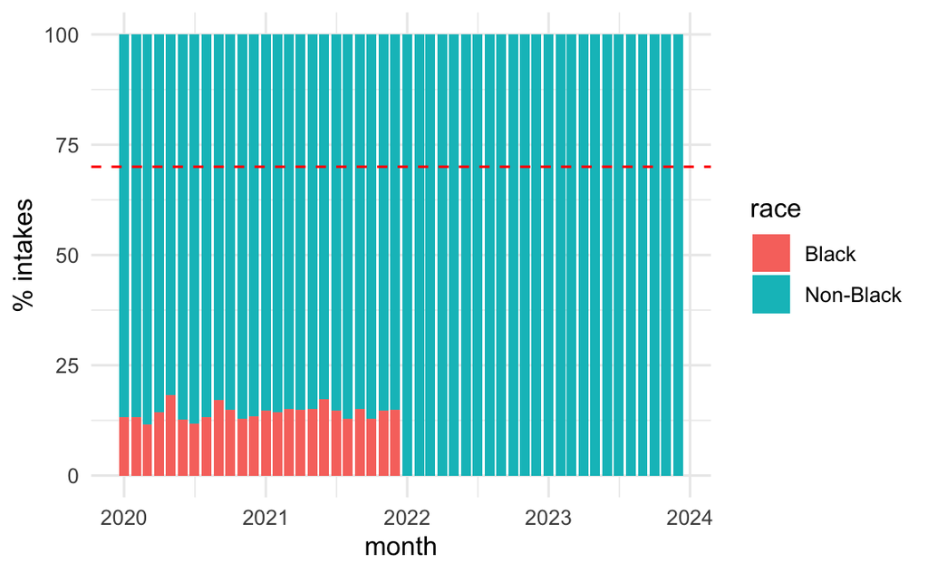